# Methods

## ARMA

```r
aic_table <- function(data,P,Q){
  table <- matrix(NA,(P+1),(Q+1))
  for(p in 0:P) {
    for(q in 0:Q) {
      table[p+1,q+1] <- arima(data,order=c(p,0,q))$aic
    }
  }
  dimnames(table) <- list(paste("AR",0:P, sep=""),
    paste("MA",0:Q,sep=""))
  table
}

bird_aic_table <- aic_table(ts_diff,5,10)
require(knitr)
kable(bird_aic_table,digits=2)
```

|  | MA0 | MA1 | MA2 | MA3 | MA4 | MA5 | MA6 | MA7 | MA8 | MA9 | MA10 |
| --- | --- | --- | --- | --- | --- | --- | --- | --- | --- | --- | --- |
| AR0 | 243.63 | 231.05 | 223.85 | 221.51 | 223.50 | 204.48 | 206.48 | 208.03 | 208.95 | 210.42 | 212.26 |
| AR1 | 238.68 | 216.84 | 218.83 | 218.29 | 220.18 | 206.48 | 208.47 | 209.76 | 210.34 | 212.34 | 214.26 |
| AR2 | 226.77 | 227.77 | 220.66 | 220.06 | 218.25 | 207.82 | 209.44 | 209.83 | 205.34 | 207.29 | 207.21 |
| AR3 | 226.94 | 222.68 | 222.17 | 207.40 | 216.69 | 208.85 | 210.07 | 204.93 | 206.14 | 215.18 | 209.20 |
| AR4 | 224.94 | 223.29 | 225.18 | 214.01 | 208.92 | 209.95 | 211.93 | 213.93 | 207.94 | 210.14 | 211.52 |
| AR5 | 221.22 | 207.85 | 209.45 | 211.16 | 211.43 | 211.93 | 213.93 | 207.19 | 209.17 | 210.48 | 212.17 |

The smaller AIC, the better the model to fit the data. Thus, ARMA(0,5) with the lowest AIC value of 204.48 is the best model.

```r
aic_table <- function(data,P,Q){
  table <- matrix(NA,(P+1),(Q+1))
  for(p in 0:P) {
    for(q in 0:Q) {
      table[p+1,q+1] <- arima(data,order=c(p,1,q))$aic
    }
  }
  dimnames(table) <- list(paste("AR",0:P, sep=""),
    paste("MA",0:Q,sep=""))
  table
}

bird_aic_table <- aic_table(ts_cpue,5,10)
require(knitr)
kable(bird_aic_table,digits=2)
```

|  | MA0 | MA1 | MA2 | MA3 | MA4 | MA5 | MA6 | MA7 | MA8 | MA9 | MA10 |
| --- | --- | --- | --- | --- | --- | --- | --- | --- | --- | --- | --- |
| AR0 | 241.91 | 229.88 | 224.34 | 224.99 | 226.80 | 210.65 | 212.64 | 213.98 | 214.21 | 216.09 | 218.09 |
| AR1 | 237.11 | 222.49 | 224.36 | 221.04 | 222.91 | 212.64 | 214.65 | 213.35 | 216.10 | 217.78 | 220.09 |
| AR2 | 225.51 | 226.64 | 224.45 | 222.73 | 224.59 | 213.85 | 215.10 | 216.03 | 211.01 | 212.92 | 212.79 |
| AR3 | 225.85 | 221.56 | 220.70 | 213.18 | 222.55 | 214.38 | 215.79 | 210.94 | 219.79 | 221.33 | 219.89 |
| AR4 | 223.60 | 222.01 | 223.92 | 219.87 | 214.87 | 215.84 | 217.77 | 217.21 | 214.08 | 215.82 | 216.93 |
| AR5 | 220.12 | 212.54 | 214.53 | 215.88 | 216.95 | 217.73 | 219.73 | 212.82 | 213.24 | 222.64 | 223.78 |

ARIMA(0,1,5) achieves the same result for original log CPUE data.

ARMA(0,5) Diagnosis

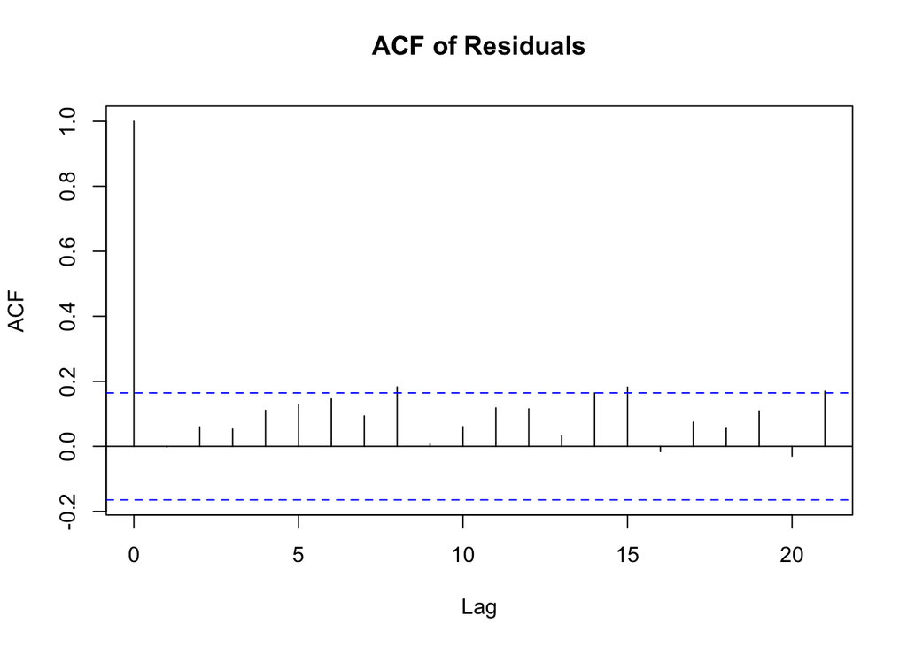

```r
fit1 <- arima(ts_cpue, order=c(0,0,5))
residuals <- residuals(fit1)

# ACF check
acf(residuals, main="ACF of Residuals")
```

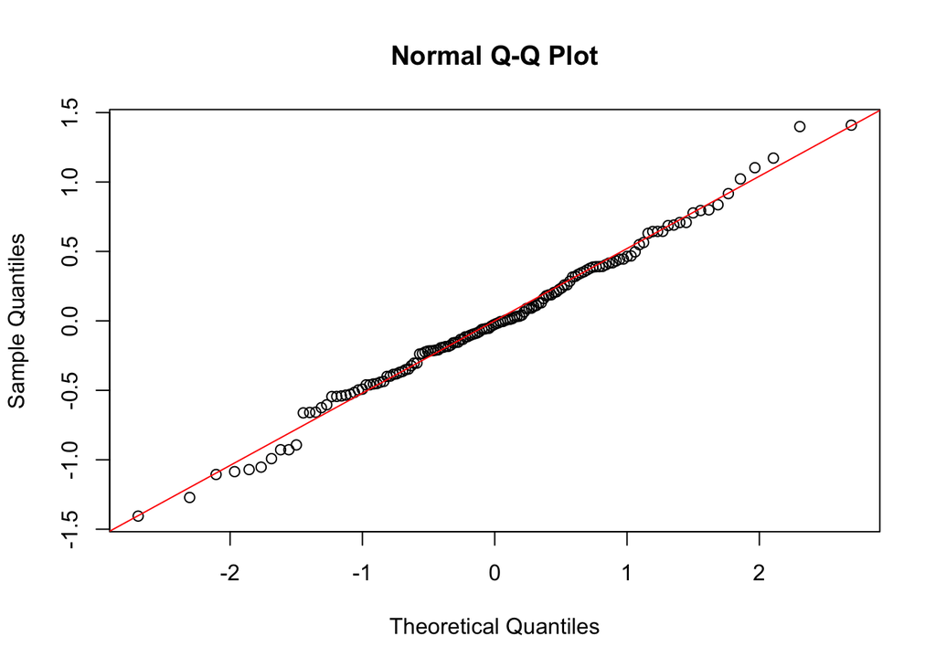

```r
# Normality check with Q-Q plot
qqnorm(residuals)
qqline(residuals, col="red")
```

```r
# Shapiro-Wilk test
shapiro.test(residuals)
```

```
##
##  Shapiro-Wilk normality test
##
## data:  residuals
## W = 0.99216, p-value = 0.6234
```

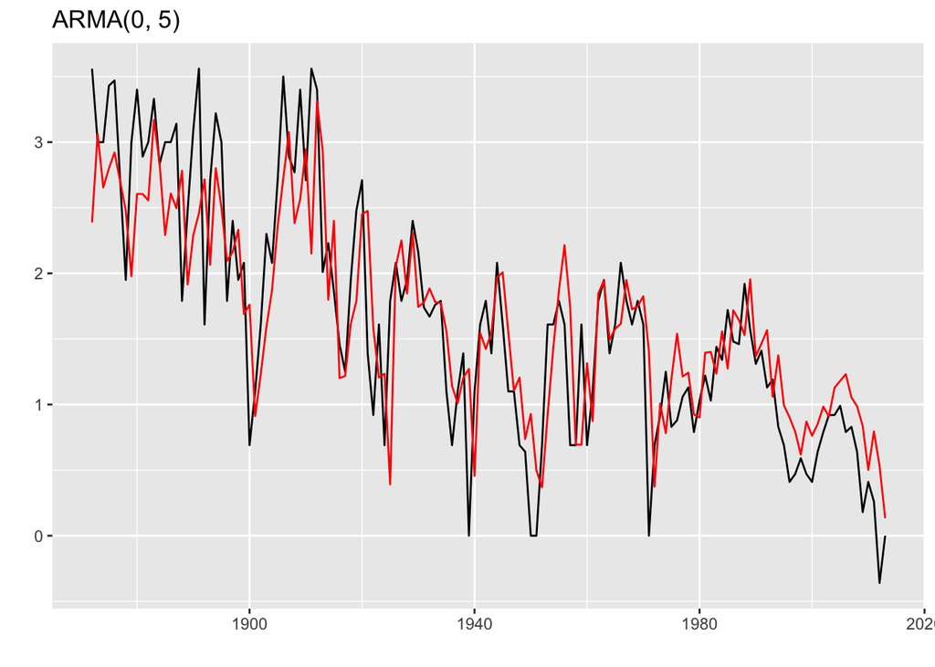

```r
# Root Check
ma_coefficients <- coef(fit1)[grepl("ma", names(coef(fit1)))]
MA_roots <- polyroot(c(1, ma_coefficients))
#invertible <- all(Mod(MA_roots) > 1)
#print(paste("Is the model invertible? ", invertible))

autoplot(fit1) +
  ggtitle("ARMA(0, 5)")
```

## POMP 1

```r
#install.packages("pomp")
library(pomp)
```

To create a POMP for CPUE, I need to define the state process that reflects the underlying dynamics of the species population and the observation process that relates the state to the CPUE measurements.